# EDA

JAGV

2023-01-23

# Week 1: Lesson 1: Graphs.

We DON’T use exploratory graphs to communicate results. Instead, exploratory graphs are the initial step in an investigation, the “quick and dirty” tool used to point the data scientist in a fruitful direction. A scientist might need to make a lot of exploratory graphs in order to develop a personal understanding of the problem being studied.

## Principles of analytic graphics.

- Principle 1: Show comparisons.
  - Remember they are always relative, so the basis has to be shown.
- Principle 2: Show causality, or mechanism or explanation or systematic structure.
  - What is your causal framework for thinking about a question?
- Principle 3: Show multivariate data. Recall the **Simpson’s paradox**.
  - Multivariate is more than 2 variables.
  - The real world is multivariate.
  - Need to escape “flatland”
- Principle 4: Integration of evidence.
  - Don’t let the tool drive the analysis: completely integrate words, numbers, images, diagrams.
- Principle 5: Describe and document the evidence with appropriate labels, scales, sources, etc.
- Principle 6: Content is king: Analytical presentations ultimately stand or fall depending on the quality, relevance, and integrity of their content.

## Exploratory graphs.

**One dimensional summaries of data:**

- Five-number summary. (minimum, the first quartile, the median, (the mean), the third quartile and the maximum). This can be obtained with the `summary` function.
- Boxplot.
- Histograms.
- Density plots.
- Barplots.

```r
x <- rexp(1000,1)
summary(x)
```

```
##    Min. 1st Qu.  Median    Mean 3rd Qu.    Max.
## 0.00051 0.30015 0.70425 1.01726 1.42862 7.27132
```

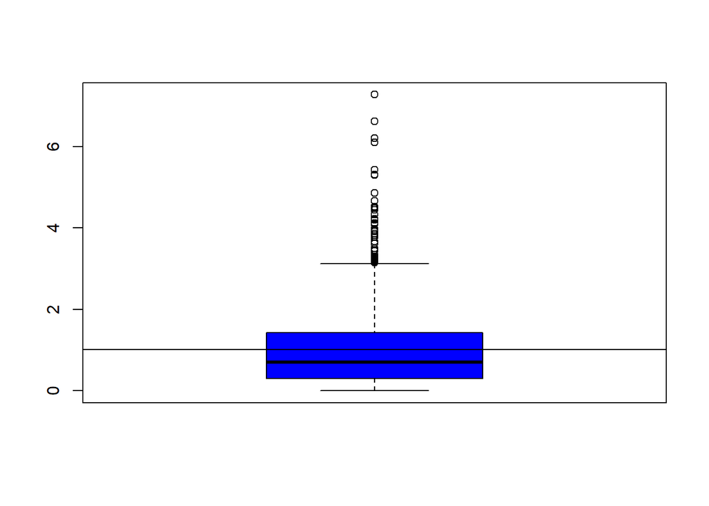

```r
boxplot(x, col = "blue")
abline(h = mean(x))
```

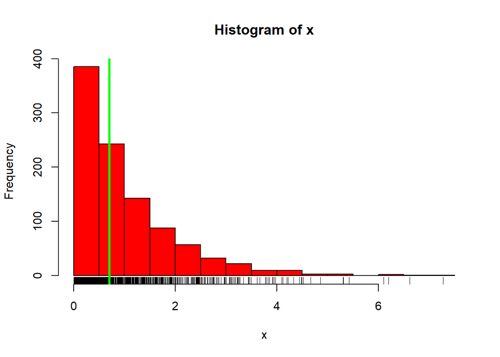

```r
hist(x, col = "red", breaks = 25)
rug(x)
abline(v = median(x), col = "green", lwd = 3)
```

**Two dimensional summaries:**

- multiple/overlayed 1-D plots.
- scatterplots.
- smooth scatterplots.

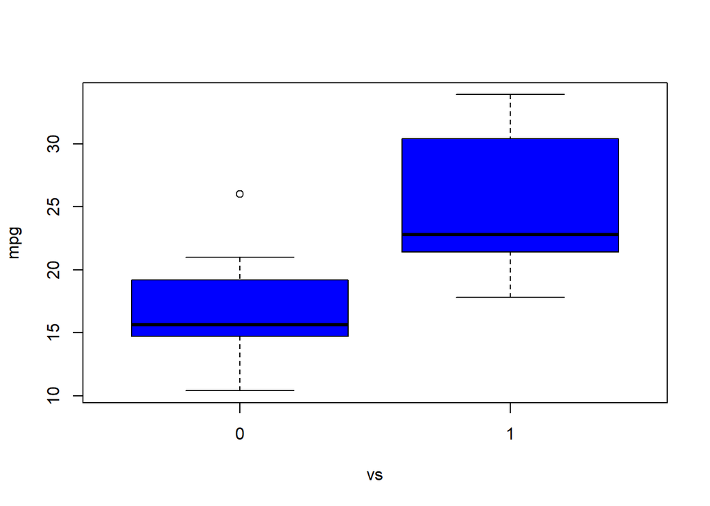

```r
data(mtcars)

boxplot(mpg ~ vs, data = mtcars, col = "blue")
```

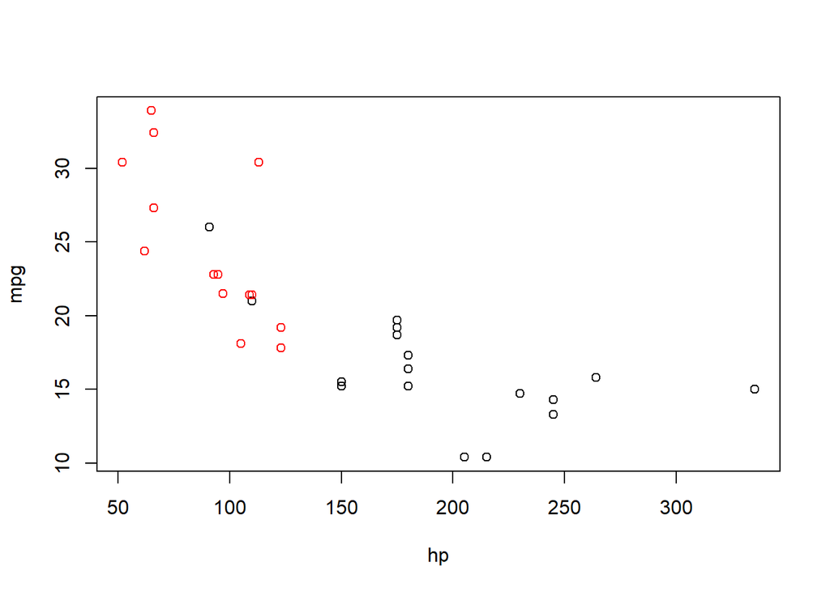

```r
with(mtcars, plot(hp, mpg, col = vs+1))
```

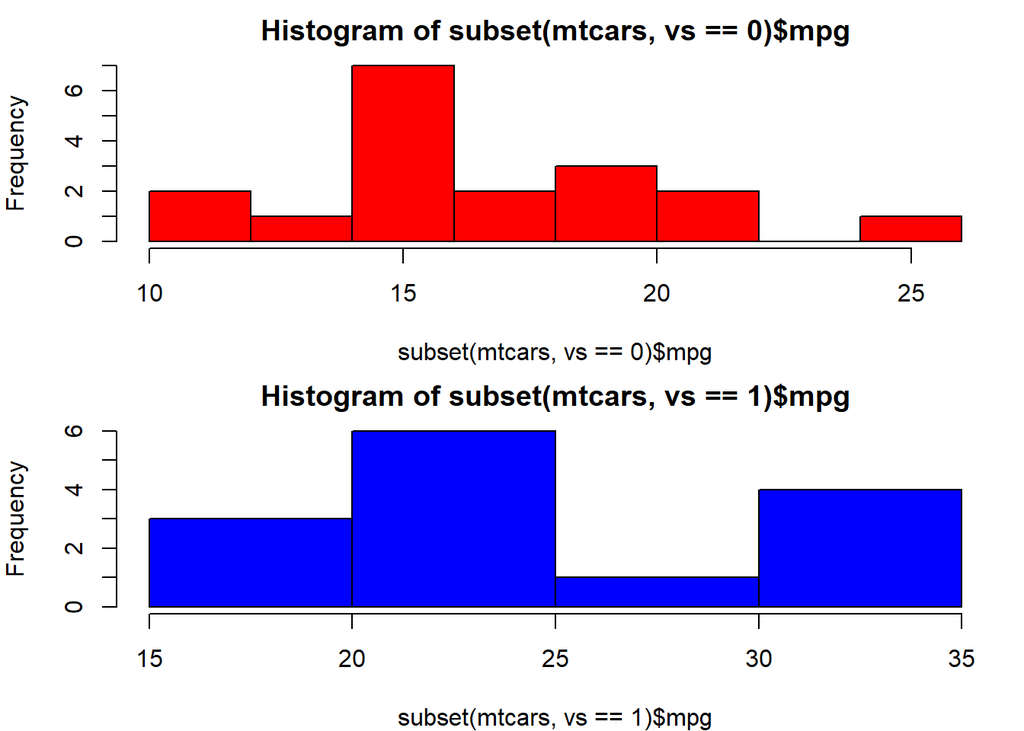

```r
par(mfrow = c(2,1), mar = c(4,4,2,1))
hist(subset(mtcars, vs == 0)$mpg, col = "red")
hist(subset(mtcars, vs == 1)$mpg, col = "blue")
```

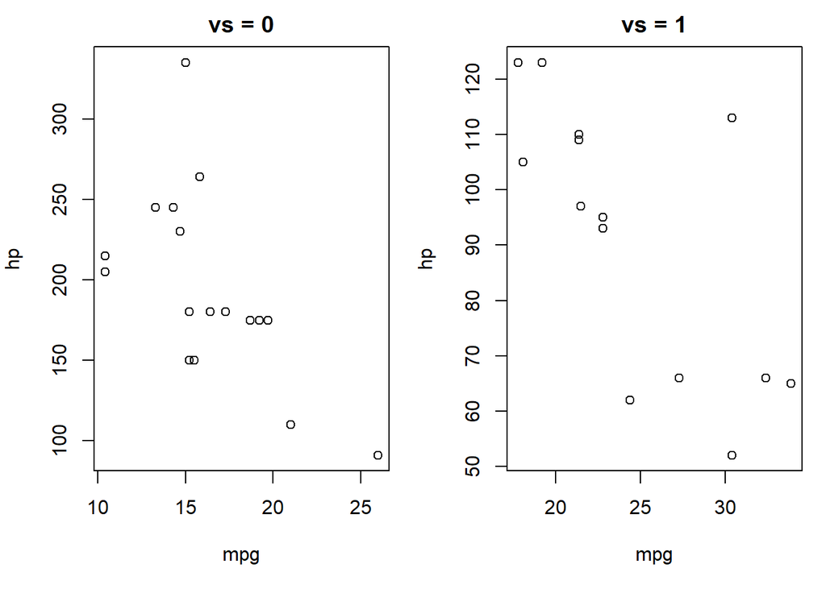

```r
par(mfrow = c(1,2), mar = c(5,4,2,1))
with(subset(mtcars, vs == 0), plot(mpg, hp, main = "vs = 0"))
with(subset(mtcars, vs == 1), plot(mpg, hp, main = "vs = 1"))
```

More than 2 dimensional summaries:

- Overlayed/multiple 2-D plots; coplots.
- Use color, size, shape to add dimensions.
- Spinning plots.
- Actual 3-D plots (not that useful).